# Workshop Microbiome Data Analysis - Day 1

Leyla Kodalci

2025-07-11

# A. Install R-packages and load libraries

Before starting the analysis, we need to install and load the required R packages.

The **DADA2** package provides the main functions for quality filtering, error modeling, and sequence inference.  
**Biostrings** and **ShortRead** are Bioconductor packages used for handling FASTQ/FASTA files. R-package **stringr** helps with working on file names and string manipulations, and **readr** is used for reading and writing tabular data.

# B. Set up working environment

In this step, we define the path to the folder that contains the raw FASTQ files and prepare the input for downstream analysis.  
A few important notes before running the code:

- Make sure to **adjust the directory path** (`reads_path`) so that it points to the folder on *your own computer* where the FASTQ files are located. Make sure to reference the **unzipped** file from the original file from Github.
- The forward reads contain `_R1_001.fastq.gz` in their filename and reverse reads contain `_R2_001.fastq.gz`.
- Filenames are expected to follow the format `SAMPLENAME_XXX.fastq.gz`. The code below will automatically extract the sample names from these filenames.
- Note: be careful with the use of backslashes (`\\`) on Windows paths. R requires double backslashes, or you can use one forward slashs (`/`).

```r
# Get path of directory that contains all of the reads
reads_path <- "C:\\Users\\lucp9827\\Desktop\\Workshop_Leyla\\Workshop_Microbiome_JKUAT_test\\Day 1\\Fastaq files\\raw.data"

# Store path of forward and reverse reads
Fs_path <- sort(list.files(reads_path, pattern="_R1_001.fastq.gz", full.names = TRUE))
Rs_path <- sort(list.files(reads_path, pattern="_R2_001.fastq.gz", full.names = TRUE))

# Create directories for processed forward and reverse reads
Fs_path_filtered <- file.path(reads_path, "filtered_Fs")
Rs_path_filtered <- file.path(reads_path, "filtered_Rs")

# Extract sample names, assuming filenames have format: SAMPLENAME_XXX.fastq.gz
sample.names <- sapply(strsplit(basename(Fs_path), "_"), `[`, 1)


names(Fs_path) <- sample.names
names(Rs_path) <- sample.names
```

# C. DADA2 workflow

## 1. Inspect quality profiles of raw reads

As a first step in the DADA2 pipeline, we visualize the quality profiles of a subset of our forward and reverse reads. This helps us to decide where to truncate the reads (remove low-quality tails).

In Illumina paired-end runs, quality usually starts to drop after ~220–240 bases for forward reads, and even earlier for reverse reads. We will use these plots to decide reasonable truncation lengths for later filtering and trimming.

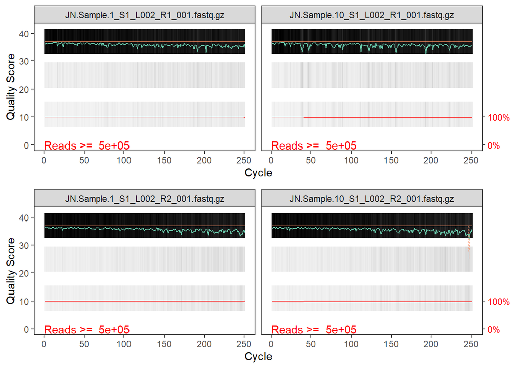

```r
p1 = plotQualityProfile(Fs_path[1:2])
p2 = plotQualityProfile(Rs_path[1:2])

print(grid.arrange(p1, p2, nrow=2))
```

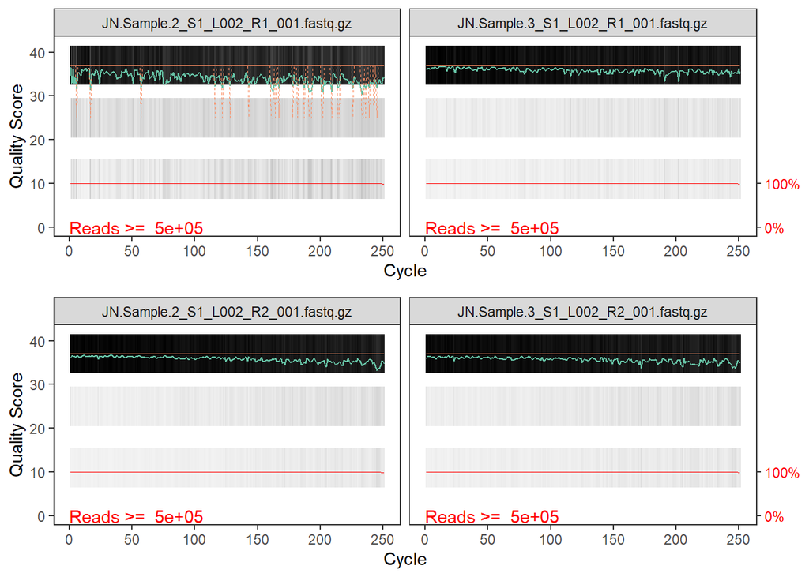

```r
p3 = plotQualityProfile(Fs_path[3:4])
p4 = plotQualityProfile(Rs_path[3:4])

print(grid.arrange(p3, p4, nrow=2))
```

**Question:**

Based on the quality profiles you see here, at which position would you truncate the forward and reverse reads in your dataset?

*Note down your chosen values,we’ll use them in the next step.*

## 2. Primer check and trimming

We will identify and remove the primers from our raw sequencing reads, since they are artificially introduced and contain no information for the downstream analysis.

First, we define the forward and reverse primer sequences and check for their presence in our FASTQ files. Because primers can appear in different orientations (forward, reverse, complement, reverse complement), we generate all possible orientations and scan for them.

!This step may take some time depending on the size of your dataset and computer speed. (15min)

```r
## Identify Primers

# Specify forward and reverse primers used
fwd_primer <- "GTGCCAGCMGCCGCGGTAA"
rev_primer <- "GGACTACVSGGGTATCTAAT"

# Function to define all orientations of the primers
allOrients <- function(primer) {
    # Create all orientations of the input sequence
    require(Biostrings)
    dna <- DNAString(primer)  # The Biostrings works w/ DNAString objects rather than character vectors
    orients <- c(Forward = dna, Complement = Biostrings::complement(dna), Reverse = Biostrings::reverse(dna),
        RevComp = Biostrings::reverseComplement(dna))
    return(sapply(orients, toString))  # Convert back to character vector
}


FWD.orients <- allOrients(fwd_primer)
REV.orients <- allOrients(rev_primer)
print(FWD.orients)
```

```
##               Forward            Complement               Reverse
## "GTGCCAGCMGCCGCGGTAA" "CACGGTCGKCGGCGCCATT" "AATGGCGCCGMCGACCGTG"
##               RevComp
## "TTACCGCGGCKGCTGGCAC"
```

```r
print(REV.orients)
```

```
##                Forward             Complement                Reverse
## "GGACTACVSGGGTATCTAAT" "CCTGATGBSCCCATAGATTA" "TAATCTATGGGSVCATCAGG"
##                RevComp
## "ATTAGATACCCSBGTAGTCC"
```

```r
primerHits <- function(primer, fn) {
    # Counts number of reads in which the primer is found
    nhits <- vcountPattern(primer, sread(readFastq(fn)), fixed = FALSE)
    return(sum(nhits > 0))
}

hits_table <- rbind(FWD.ForwardReads = sapply(FWD.orients, primerHits, fn = Fs_path[[1]]), FWD.ReverseReads = sapply(FWD.orients,
    primerHits, fn = Rs_path[[1]]), REV.ForwardReads = sapply(REV.orients, primerHits,
    fn = Fs_path[[1]]), REV.ReverseReads = sapply(REV.orients, primerHits, fn = Rs_path[[1]]))

print(hits_table)
```

```
##                  Forward Complement Reverse RevComp
## FWD.ForwardReads  835660          0       0       0
## FWD.ReverseReads       9          0       0     294
## REV.ForwardReads      12          0       0     302
## REV.ReverseReads  820906          0       0       0
```

**Questions:**

1. Do the forward primers mainly occur in the forward reads, and reverse primers in the reverse reads?
2. Are there any unexpected hits?
3. What does this tell you about trimming?

Now that we have confirmed the presence of primers in our raw reads, the next step is to **remove primers and trim the reads**. We use the known primer lengths (`lenF` and `lenR`) to cut the primer sequences from the start of each read (`trimLeft`). We then truncate the reads at positions where quality typically begins to drop (`truncLen`). Here, we use *240* bases for forward reads and *240* bases for reverse reads as example values but these should be adjusted based on your own quality profiles.

Additional filtering options:

- `maxEE` = maximum expected errors allowed per read (a more reliable filter than average quality score).
- `rm.phix=TRUE` removes any reads that match the PhiX control genome (commonly included in Illumina runs).
- `compress=TRUE` ensures that output files are written in compressed `.gz` format.
- The truncation lengths (`truncLen`) should be chosen carefully from your quality plots. If they are too short, you may lose overlap between forward and reverse reads; if too long, you may keep low-quality bases that introduce errors.

```r
## Primer removal and Trimming

# Lengths of your forward and reverse primers
lenF <- nchar(fwd_primer)
lenR <- nchar(rev_primer)


out <- filterAndTrim(Fs_path, Fs_path_filtered,
                     Rs_path, Rs_path_filtered,
                     trimLeft=c(lenF, lenR),   # remove primers
                     truncLen=c(240,240),     # example truncation
                     maxEE=c(2,2),
                     truncQ=2,
                     rm.phix=TRUE,
                     compress=TRUE)

print(out)
```

```
##                                      reads.in reads.out
## JN.Sample.1_S1_L002_R1_001.fastq.gz    870304    789520
## JN.Sample.10_S1_L002_R1_001.fastq.gz   642484    576711
## JN.Sample.2_S1_L002_R1_001.fastq.gz    688733    554502
## JN.Sample.3_S1_L002_R1_001.fastq.gz    886019    802142
## JN.Sample.4_S1_L002_R1_001.fastq.gz    654121    587753
## JN.Sample.5_S1_L002_R1_001.fastq.gz    699568    629065
## JN.Sample.6_S1_L002_R1_001.fastq.gz    719468    656168
## JN.Sample.7_S1_L002_R1_001.fastq.gz    616345    553673
## JN.Sample.8_S1_L002_R1_001.fastq.gz    805764    730478
## JN.Sample.9_S1_L002_R1_001.fastq.gz    690961    630434
```

```r
## Visualiasing retention after filtering

# Convert to dataframe
out_df <- as.data.frame(out)
out_df$Sample <- rownames(out_df)

# Calculate percentage retained
out_df$perc_retained <- (out_df$reads.out / out_df$reads.in) * 100
print(out_df)
```

```
##                                      reads.in reads.out
## JN.Sample.1_S1_L002_R1_001.fastq.gz    870304    789520
## JN.Sample.10_S1_L002_R1_001.fastq.gz   642484    576711
## JN.Sample.2_S1_L002_R1_001.fastq.gz    688733    554502
## JN.Sample.3_S1_L002_R1_001.fastq.gz    886019    802142
## JN.Sample.4_S1_L002_R1_001.fastq.gz    654121    587753
## JN.Sample.5_S1_L002_R1_001.fastq.gz    699568    629065
## JN.Sample.6_S1_L002_R1_001.fastq.gz    719468    656168
## JN.Sample.7_S1_L002_R1_001.fastq.gz    616345    553673
## JN.Sample.8_S1_L002_R1_001.fastq.gz    805764    730478
## JN.Sample.9_S1_L002_R1_001.fastq.gz    690961    630434
##                                                                    Sample
## JN.Sample.1_S1_L002_R1_001.fastq.gz   JN.Sample.1_S1_L002_R1_001.fastq.gz
## JN.Sample.10_S1_L002_R1_001.fastq.gz JN.Sample.10_S1_L002_R1_001.fastq.gz
## JN.Sample.2_S1_L002_R1_001.fastq.gz   JN.Sample.2_S1_L002_R1_001.fastq.gz
## JN.Sample.3_S1_L002_R1_001.fastq.gz   JN.Sample.3_S1_L002_R1_001.fastq.gz
## JN.Sample.4_S1_L002_R1_001.fastq.gz   JN.Sample.4_S1_L002_R1_001.fastq.gz
## JN.Sample.5_S1_L002_R1_001.fastq.gz   JN.Sample.5_S1_L002_R1_001.fastq.gz
## JN.Sample.6_S1_L002_R1_001.fastq.gz   JN.Sample.6_S1_L002_R1_001.fastq.gz
## JN.Sample.7_S1_L002_R1_001.fastq.gz   JN.Sample.7_S1_L002_R1_001.fastq.gz
## JN.Sample.8_S1_L002_R1_001.fastq.gz   JN.Sample.8_S1_L002_R1_001.fastq.gz
## JN.Sample.9_S1_L002_R1_001.fastq.gz   JN.Sample.9_S1_L002_R1_001.fastq.gz
##                                      perc_retained
## JN.Sample.1_S1_L002_R1_001.fastq.gz       90.71773
## JN.Sample.10_S1_L002_R1_001.fastq.gz      89.76270
## JN.Sample.2_S1_L002_R1_001.fastq.gz       80.51044
## JN.Sample.3_S1_L002_R1_001.fastq.gz       90.53327
## JN.Sample.4_S1_L002_R1_001.fastq.gz       89.85386
## JN.Sample.5_S1_L002_R1_001.fastq.gz       89.92192
## JN.Sample.6_S1_L002_R1_001.fastq.gz       91.20183
## JN.Sample.7_S1_L002_R1_001.fastq.gz       89.83167
## JN.Sample.8_S1_L002_R1_001.fastq.gz       90.65657
## JN.Sample.9_S1_L002_R1_001.fastq.gz       91.24017
```

The code below is a check to see the trimming and filtering effects on the raw reads.

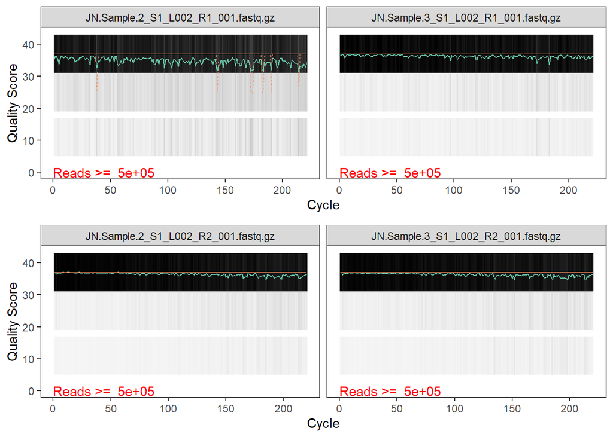

```r
## Sanity check: Quality profiles

# Store path of forward and reverse filetered reads
fil_Fs_path <- sort(list.files(Fs_path_filtered, pattern="_R1_001.fastq.gz", full.names = TRUE))
fil_Rs_path <- sort(list.files(Rs_path_filtered, pattern="_R2_001.fastq.gz", full.names = TRUE))

p3 = plotQualityProfile(fil_Fs_path[3:4])
p4 = plotQualityProfile(fil_Rs_path[3:4])

print(grid.arrange(p3, p4, nrow=2))
```

```r
# Primer hits

hits_table <- rbind(FWD.ForwardReads = sapply(FWD.orients, primerHits, fn = fil_Fs_path[[1]]), FWD.ReverseReads = sapply(FWD.orients,
    primerHits, fn = fil_Rs_path[[1]]), REV.ForwardReads = sapply(REV.orients, primerHits,
    fn = fil_Fs_path[[1]]), REV.ReverseReads = sapply(REV.orients, primerHits, fn = fil_Rs_path[[1]]))

print(hits_table)
```

```
##                  Forward Complement Reverse RevComp
## FWD.ForwardReads       4          0       0       0
## FWD.ReverseReads       0          0       0       0
## REV.ForwardReads       0          0       0       3
## REV.ReverseReads       7          0       0       0
```

**Questions:**

1. Are there large differences between the raw and filtered read counts? If yes, what might explain the loss reads?
2. Why is it important to check these numbers before moving on to the next step in the pipeline?
3. After filtering, do your reads appear shorter by the number of bases corresponding to the primer length?
4. After removing the primers with `trimLeft`, are there still primers found in the reads? If yes, why would you think these hits are still present?

## 3. Learning the error rates

After filtering and trimming, DADA2 needs to learn the **error rates** in the sequencing data. Sequencing machines introduce errors (substitutions, insertions, deletions) that we must model in order to distinguish true biological variation from technical noise.

- The `learnErrors()` function estimates these error rates directly from your dataset. DADA2 then uses this information to accurately infer real amplicon sequence variants (ASVs).
- The `plotErrors()` function visualises the estimated error rates and compares them to the expected quality scores. Ideally, the points (observed errors) should closely follow the black line (expected).

Note: As this step takes some time to run, we have **precomputed the error models** for you.  
You can **load them immediately** and continue, or run the full computation yourself (e.g., after the worlshopor overnight).

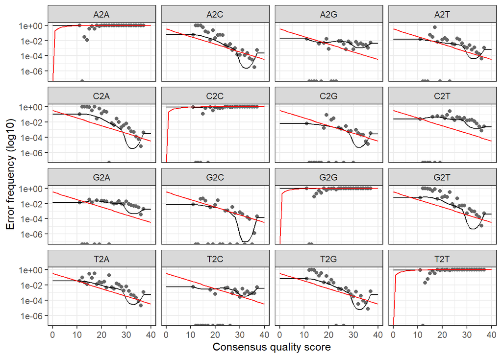

```r
## Code to learn error rates
# errF <- learnErrors(fil_Fs_path,nbases = 1e7, multithread=TRUE)
# errR <- learnErrors(fil_Rs_path,nbases = 1e7, multithread=TRUE)

## Loas in error rates
path_error = "C:\\Users\\lucp9827\\Desktop\\Workshop_Leyla\\Workshop_Microbiome_JKUAT_test\\Day 1\\Data\\"

load(paste0(path_error,"errorsF.RData"))
load(paste0(path_error,"errorsR.RData"))

# Plot error rates

plotErrors(errF, nominalQ=TRUE)
```

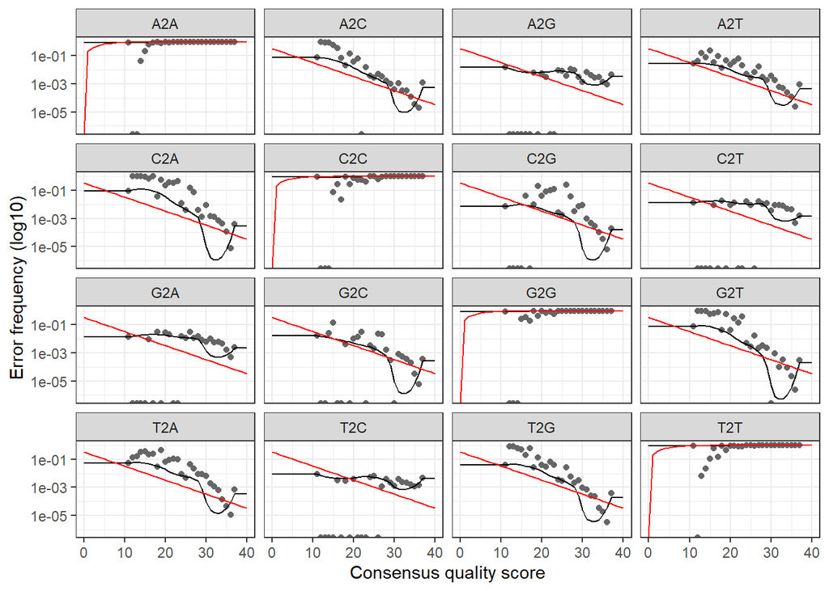

```r
plotErrors(errR, nominalQ=TRUE)
```

**Questions:**

1. Looking at this plot , do you think our error model is well fitted?
2. If you see a more horizontal error line, does that mean something went wrong?
3. What would you check if the observed points were very far from the fitted black line?

## 4. Sample inference

Once error rates have been learned, the next step is to dereplicate the reads and apply the DADA2 core algorithm.

- **Dereplication**: identical sequencing reads within each sample are collapsed into unique sequences with their abundances recorded. This dramatically reduces computation time. It also allows the algorithm to model abundance information, which helps distinguish true variants from sequencing errors.
- **Sample inference with `dada()`**: Using the learned error model, DADA2 compares each unique sequence against the expected error rates. It determines whether a sequence is most likely a real **amplicon sequence variant (ASV)** or simply the result of an error from a more abundant sequence. This step is the heart of the DADA2 pipeline, where noisy reads are turned into high-resolution biological sequences.

Note: As dada allogorithm takes some time to run, we have **precomputed the core algorithm** for you.  
You can **load them immediately** and continue, or run the full computation yourself (e.g., after workshop or overnight).

```r
# Dereplication
derep_forward <- derepFastq(fil_Fs_path, verbose = TRUE)
```

```
## Dereplicating sequence entries in Fastq file: C:\Users\lucp9827\Desktop\Workshop_Leyla\Workshop_Microbiome_JKUAT_test\Day 1\Fastaq files\raw.data/filtered_Fs/JN.Sample.1_S1_L002_R1_001.fastq.gz
```

```
## Encountered 193288 unique sequences from 789520 total sequences read.
```

```
## Dereplicating sequence entries in Fastq file: C:\Users\lucp9827\Desktop\Workshop_Leyla\Workshop_Microbiome_JKUAT_test\Day 1\Fastaq files\raw.data/filtered_Fs/JN.Sample.10_S1_L002_R1_001.fastq.gz
```

```
## Encountered 68166 unique sequences from 576711 total sequences read.
```

```
## Dereplicating sequence entries in Fastq file: C:\Users\lucp9827\Desktop\Workshop_Leyla\Workshop_Microbiome_JKUAT_test\Day 1\Fastaq files\raw.data/filtered_Fs/JN.Sample.2_S1_L002_R1_001.fastq.gz
```

```
## Encountered 194034 unique sequences from 554502 total sequences read.
```

```
## Dereplicating sequence entries in Fastq file: C:\Users\lucp9827\Desktop\Workshop_Leyla\Workshop_Microbiome_JKUAT_test\Day 1\Fastaq files\raw.data/filtered_Fs/JN.Sample.3_S1_L002_R1_001.fastq.gz
```

```
## Encountered 154228 unique sequences from 802142 total sequences read.
```

```
## Dereplicating sequence entries in Fastq file: C:\Users\lucp9827\Desktop\Workshop_Leyla\Workshop_Microbiome_JKUAT_test\Day 1\Fastaq files\raw.data/filtered_Fs/JN.Sample.4_S1_L002_R1_001.fastq.gz
```

```
## Encountered 136569 unique sequences from 587753 total sequences read.
```

```
## Dereplicating sequence entries in Fastq file: C:\Users\lucp9827\Desktop\Workshop_Leyla\Workshop_Microbiome_JKUAT_test\Day 1\Fastaq files\raw.data/filtered_Fs/JN.Sample.5_S1_L002_R1_001.fastq.gz
```

```
## Encountered 109747 unique sequences from 629065 total sequences read.
```

```
## Dereplicating sequence entries in Fastq file: C:\Users\lucp9827\Desktop\Workshop_Leyla\Workshop_Microbiome_JKUAT_test\Day 1\Fastaq files\raw.data/filtered_Fs/JN.Sample.6_S1_L002_R1_001.fastq.gz
```

```
## Encountered 104947 unique sequences from 656168 total sequences read.
```

```
## Dereplicating sequence entries in Fastq file: C:\Users\lucp9827\Desktop\Workshop_Leyla\Workshop_Microbiome_JKUAT_test\Day 1\Fastaq files\raw.data/filtered_Fs/JN.Sample.7_S1_L002_R1_001.fastq.gz
```

```
## Encountered 63871 unique sequences from 553673 total sequences read.
```

```
## Dereplicating sequence entries in Fastq file: C:\Users\lucp9827\Desktop\Workshop_Leyla\Workshop_Microbiome_JKUAT_test\Day 1\Fastaq files\raw.data/filtered_Fs/JN.Sample.8_S1_L002_R1_001.fastq.gz
```

```
## Encountered 114028 unique sequences from 730478 total sequences read.
```

```
## Dereplicating sequence entries in Fastq file: C:\Users\lucp9827\Desktop\Workshop_Leyla\Workshop_Microbiome_JKUAT_test\Day 1\Fastaq files\raw.data/filtered_Fs/JN.Sample.9_S1_L002_R1_001.fastq.gz
```

```
## Encountered 119406 unique sequences from 630434 total sequences read.
```

```r
derep_reverse <- derepFastq(fil_Rs_path, verbose = TRUE)
```

```
## Dereplicating sequence entries in Fastq file: C:\Users\lucp9827\Desktop\Workshop_Leyla\Workshop_Microbiome_JKUAT_test\Day 1\Fastaq files\raw.data/filtered_Rs/JN.Sample.1_S1_L002_R2_001.fastq.gz
```

```
## Encountered 171210 unique sequences from 789520 total sequences read.
```

```
## Dereplicating sequence entries in Fastq file: C:\Users\lucp9827\Desktop\Workshop_Leyla\Workshop_Microbiome_JKUAT_test\Day 1\Fastaq files\raw.data/filtered_Rs/JN.Sample.10_S1_L002_R2_001.fastq.gz
```

```
## Encountered 75691 unique sequences from 576711 total sequences read.
```

```
## Dereplicating sequence entries in Fastq file: C:\Users\lucp9827\Desktop\Workshop_Leyla\Workshop_Microbiome_JKUAT_test\Day 1\Fastaq files\raw.data/filtered_Rs/JN.Sample.2_S1_L002_R2_001.fastq.gz
```

```
## Encountered 94370 unique sequences from 554502 total sequences read.
```

```
## Dereplicating sequence entries in Fastq file: C:\Users\lucp9827\Desktop\Workshop_Leyla\Workshop_Microbiome_JKUAT_test\Day 1\Fastaq files\raw.data/filtered_Rs/JN.Sample.3_S1_L002_R2_001.fastq.gz
```

```
## Encountered 139157 unique sequences from 802142 total sequences read.
```

```
## Dereplicating sequence entries in Fastq file: C:\Users\lucp9827\Desktop\Workshop_Leyla\Workshop_Microbiome_JKUAT_test\Day 1\Fastaq files\raw.data/filtered_Rs/JN.Sample.4_S1_L002_R2_001.fastq.gz
```

```
## Encountered 116149 unique sequences from 587753 total sequences read.
```

```
## Dereplicating sequence entries in Fastq file: C:\Users\lucp9827\Desktop\Workshop_Leyla\Workshop_Microbiome_JKUAT_test\Day 1\Fastaq files\raw.data/filtered_Rs/JN.Sample.5_S1_L002_R2_001.fastq.gz
```

```
## Encountered 100323 unique sequences from 629065 total sequences read.
```

```
## Dereplicating sequence entries in Fastq file: C:\Users\lucp9827\Desktop\Workshop_Leyla\Workshop_Microbiome_JKUAT_test\Day 1\Fastaq files\raw.data/filtered_Rs/JN.Sample.6_S1_L002_R2_001.fastq.gz
```

```
## Encountered 95722 unique sequences from 656168 total sequences read.
```

```
## Dereplicating sequence entries in Fastq file: C:\Users\lucp9827\Desktop\Workshop_Leyla\Workshop_Microbiome_JKUAT_test\Day 1\Fastaq files\raw.data/filtered_Rs/JN.Sample.7_S1_L002_R2_001.fastq.gz
```

```
## Encountered 67044 unique sequences from 553673 total sequences read.
```

```
## Dereplicating sequence entries in Fastq file: C:\Users\lucp9827\Desktop\Workshop_Leyla\Workshop_Microbiome_JKUAT_test\Day 1\Fastaq files\raw.data/filtered_Rs/JN.Sample.8_S1_L002_R2_001.fastq.gz
```

```
## Encountered 118480 unique sequences from 730478 total sequences read.
```

```
## Dereplicating sequence entries in Fastq file: C:\Users\lucp9827\Desktop\Workshop_Leyla\Workshop_Microbiome_JKUAT_test\Day 1\Fastaq files\raw.data/filtered_Rs/JN.Sample.9_S1_L002_R2_001.fastq.gz
```

```
## Encountered 117753 unique sequences from 630434 total sequences read.
```

```r
## Apply the core sample inference algorithm to the dereplicated data
#dadaFs <- dada(derep_forward, err=errF, multithread=TRUE)
#dadaRs <- dada(derep_reverse, err=errR, multithread=TRUE)


## Load results of dada core algorithm
path_core = "C:\\Users\\lucp9827\\Desktop\\Workshop_Leyla\\Workshop_Microbiome_JKUAT_test\\Day 1\\Data\\"

load(paste0(path_core,"dadaFs.RData"))
load(paste0(path_core,"dadaRs.RData"))


print(dadaFs[[1]])
```

```
## dada-class: object describing DADA2 denoising results
## 2805 sequence variants were inferred from 193288 input unique sequences.
## Key parameters: OMEGA_A = 1e-40, OMEGA_C = 1e-40, BAND_SIZE = 16
```

```r
print(dadaRs[[1]])
```

```
## dada-class: object describing DADA2 denoising results
## 2493 sequence variants were inferred from 171210 input unique sequences.
## Key parameters: OMEGA_A = 1e-40, OMEGA_C = 1e-40, BAND_SIZE = 16
```

**Question:**

Why do we expect the number of unique sequences to be much higher than the actual number of true variants?

## 5. Merge paired reads

In this step, we merge the forward and reverse reads back together to reconstruct the full amplicon sequence.

- `mergePairs()` aligns each forward and reverse read by their overlapping region. By default, merged sequences are only kept if the forward and reverse reads overlap by min. 12 bases and are identical to each other in the overlap region.

```r
mergers <- mergePairs(dadaFs, fil_Fs_path, dadaRs, fil_Rs_path, verbose=TRUE)
```

```
## 719558 paired-reads (in 3371 unique pairings) successfully merged out of 775443 (in 16874 pairings) input.
```

```
## 543351 paired-reads (in 499 unique pairings) successfully merged out of 570818 (in 1787 pairings) input.
```

```
## 519711 paired-reads (in 1437 unique pairings) successfully merged out of 549152 (in 7125 pairings) input.
```

```
## 756996 paired-reads (in 3093 unique pairings) successfully merged out of 792859 (in 11770 pairings) input.
```

```
## 551964 paired-reads (in 2048 unique pairings) successfully merged out of 580072 (in 8419 pairings) input.
```

```
## 599630 paired-reads (in 1650 unique pairings) successfully merged out of 623074 (in 6816 pairings) input.
```

```
## 631201 paired-reads (in 1240 unique pairings) successfully merged out of 650856 (in 4893 pairings) input.
```

```
## 538325 paired-reads (in 1364 unique pairings) successfully merged out of 549495 (in 3952 pairings) input.
```

```
## 680471 paired-reads (in 3237 unique pairings) successfully merged out of 719587 (in 13308 pairings) input.
```

```
## 585684 paired-reads (in 2824 unique pairings) successfully merged out of 619607 (in 12172 pairings) input.
```

```r
# Inspect the merger data.frame from the first sample
head(mergers[[1]])
```

```
##                                                                                                                                                                                                                                                        sequence
## 1 TACAGAGGGTGCAAGCGTTAATCGGAATTACTGGGCGTAAAGCGCGCGTAGGTGGTTCGT…
## 2 TACGTAGGGTGCGAGCGTTAATCGGAATTACTGGGCGTAAAGCGTGCGCAGGCGGTTATG…
## 3 TACGTAGGTGGCAAGCGTTGTCCGGATTTATTGGGCGTAAAGCGAGCGCAGGCGGTTTCT…
## 4 TACGAAGGGGGCTAGCGTTGCTCGGAATGACTGGGCGTAAAGGGCGTGTAGGCGGTTTAC…
## 5 TACGTAGGGTGCGAGCGTTAATCGGAATTACTGGGCGTAAAGCGTGCGCAGGCGGTTTTG…
## 6 TACGGAGGGTGCAAGCGTTAATCGGAATTACTGGGCGTAAAGCGCACGCAGGCGGTCTGT…
##   abundance forward reverse nmatch nmismatch nindel prefer accept
## 1    128981       1       1    188         0      0      2   TRUE
## 2     42836       2       2    188         0      0      2   TRUE
## 3     19424       3       3    188         0      0      1   TRUE
## 4     15392       4       6    188         0      0      2   TRUE
## 5     12946       5       5    188         0      0      2   TRUE
## 6     12194       6       4    188         0      0      2   TRUE
```

**Questions:**

1. What percentage of reads were succesfully merged for your samples? (Hint: check messages in R-console)
2. What does a high proportion of successfully merged reads tell us about our chosen truncation lengths and read overlap?
3. How can we interpret the result for sample 1?

## 5. Construct sequence table

We can now construct an amplicon sequence variant table (ASV) table.

```r
seqtab <- makeSequenceTable(mergers)

dim(seqtab)
```

```
## [1]    10 16112
```

```r
# Inspect distribution of sequence lengths
table(nchar(getSequences(seqtab)))
```

```
##
##   221   222   223   224   226   228   229   232   233   236   240   241   250
##     1     1     1     1     1     1     2     4     1     3     1     2     1
##   251   252   253   254   255   256   270   271   272   273   274   275   276
##    71   339 15626    36     1     2     1     1     2     1     2     1     1
##   280   282   286   292   293   295   356
##     1     1     2     1     1     1     1
```

**Question:**

1. How many ASVs where identified?
2. What does the sequence length distribution tell us?

## 6. Remove chimeras

Chimeras are artificial sequences formed during PCR when two parent DNA fragments are incorrectly joined together. They are common in amplicon sequencing and, if not removed, can inflate diversity estimates by introducing spurious variants.

In this step, we use `removeBimeraDenovo()` to identify and remove chimeric sequences. The `method="consensus"` option compares each sequence to others in the dataset and flags sequences that can be explained as a combination of more abundant “parent” sequences.

Note: if a very large fraction of reads are flagged as chimeric, it may indicate issues with primer trimming, sequencing quality, or overly aggressive parameters in previous steps.

```r
seqtab.nochim <- removeBimeraDenovo(seqtab, method="consensus", multithread=TRUE, verbose=TRUE)
```

```
## Identified 14765 bimeras out of 16112 input sequences.
```

```r
dim(seqtab.nochim)
```

```
## [1]   10 1347
```

```r
sum(seqtab.nochim)/sum(seqtab)
```

```
## [1] 0.5884885
```

**Questions:**

1. What fraction of reads were retained after chimera removal?
2. Why is it expected that such a large fraction of unique sequences are removed as chimeras?

## 7. Track reads

Before assigning taxonomy, it is important to check how many reads remain at each step of the pipeline. This helps us verify that our filtering, denoising, merging, and chimera removal worked as expected and that we still have enough data per sample for reliable downstream analysis.

The tracking table shows how reads were progressively reduced from raw input to the final non-chimeric sequences. Some read loss is normal (and desirable, since we remove low-quality reads and artifacts), but very low retention could signal problems with quality, filtering parameters, or specific samples.

```r
getN <- function(x) sum(getUniques(x))

track <- cbind(out, sapply(dadaFs, getN), sapply(dadaRs, getN), sapply(mergers, getN), rowSums(seqtab.nochim))

colnames(track) <- c("input", "filtered", "denoisedF", "denoisedR", "merged", "nonchim")
rownames(track) <- sample.names

print(track)
```

```
##               input filtered denoisedF denoisedR merged nonchim
## JN.Sample.1  870304   789520    780258    782790 719558  321223
## JN.Sample.10 642484   576711    574098    573137 543351  358734
## JN.Sample.2  688733   554502    551468    551743 519711  279328
## JN.Sample.3  886019   802142    796577    797443 756996  385436
## JN.Sample.4  654121   587753    582790    584045 551964  280065
## JN.Sample.5  699568   629065    625346    626005 599630  389376
## JN.Sample.6  719468   656168    652891    653614 631201  314913
## JN.Sample.7  616345   553673    551256    551288 538325  421704
## JN.Sample.8  805764   730478    723490    724599 680471  478000
## JN.Sample.9  690961   630434    623037    624853 585684  376826
```

**Questions**:

- At which step do we lose the largest proportion of reads across samples? Why do you think that happens?
- Why is it okay (and even necessary) to lose such a large fraction of reads during filtering and chimera removal?
- Looking across samples, are there any that stand out with unusually high or low retention? What could that mean about data quality?
- If a sample ended with very few non-chimeric reads, what would that mean for its downstream analysis?

## 8. Assign taxonomy

Now that we have obtained a high-quality set of non-chimeric ASVs, the next step is to assign taxonomy to these sequences. This allows us to connect each ASV to known microbial groups and interpret the biological meaning of our dataset.

- We use the **`assignTaxonomy()`** function in DADA2 to classify ASVs against a curated reference database. Here we use the **SILVA v138.2 database**, one of the most comprehensive 16S/18S rRNA reference sets. These DADA2-formatted [training fasta files were derived from the Silva Project’s version 138.2 release](https://zenodo.org/records/14169026): https://www.arb-silva.de/.
- The taxonomy assignment proceeds from higher to lower ranks (Kingdom → Phylum → Class → Order → Family → Genus).
- We then refine the classification with **`addSpecies()`**, which compares sequences to exact matches in the reference database to assign species names when possible.
- The resulting table (`taxa`) gives us the taxonomic identity of each ASV, which is essential for downstream analyses such as community composition, diversity, and differential abundance.

```r
taxa <- assignTaxonomy(seqtab.nochim, "C:\\Users\\lucp9827\\Desktop\\Workshop_Leyla\\Workshop_Microbiome_JKUAT_test\\Day 1\\Data/silva_nr99_v138.2_toSpecies_trainset.fa.gz", multithread=TRUE)

taxa <- addSpecies(taxa, "C:\\Users\\lucp9827\\Desktop\\Workshop_Leyla\\Workshop_Microbiome_JKUAT_test\\Day 1\\Data/silva_v138.2_assignSpecies.fa.gz")


taxa.print <- taxa # Removing sequence rownames for display only
rownames(taxa.print) <- NULL
print(head(taxa.print))
```

```
##      Kingdom    Phylum           Class                 Order
## [1,] "Bacteria" "Pseudomonadota" "Alphaproteobacteria" "Hyphomicrobiales"
## [2,] "Bacteria" "Pseudomonadota" "Gammaproteobacteria" "Pseudomonadales"
## [3,] "Bacteria" "Bacillota"      "Bacilli"             "Staphylococcales"
## [4,] "Bacteria" "Bacillota"      "Bacilli"             "Bacillales"
## [5,] "Bacteria" "Pseudomonadota" "Gammaproteobacteria" "Enterobacterales"
## [6,] "Bacteria" "Bacillota"      "Bacilli"             "Lactobacillales"
##      Family              Genus            Species         Species
## [1,] "Xanthobacteraceae" "Bradyrhizobium" NA              NA
## [2,] "Pseudomonadaceae"  "Pseudomonas"    "cichorii"      NA
## [3,] "Staphylococcaceae" "Staphylococcus" "aureus"        NA
## [4,] "Planococcaceae"    "Sporosarcina"   NA              NA
## [5,] "Yersiniaceae"      "Serratia"       NA              NA
## [6,] "Lactobacillaceae"  "Leuconostoc"    "mesenteroides" NA
```

```r
# Count how many ASVs got a genus assignment
sum(!is.na(taxa[, "Genus"]))
```

```
## [1] 878
```

```r
# Count how many ASVs got a species assignment
sum(!is.na(taxa[, "Species"]))
```

```
## [1] 166
```

```r
# Proportion of ASVs with species-level classification
sum(!is.na(taxa[, "Species"])) / nrow(taxa)
```

```
## [1] 0.1232368
```

**Questions:**

Why do you think there are usually fewer ASVs with species-level assignments than genus-level?

## 9. Convert to phyloseq-object

We combine our ASV table (`seqtab.nochim`), taxonomy table (`taxa`), and sample metadata into a `phyloseq` object. This makes downstream microbiome analysis much easier, because all components are stored in one structured format.

A `phyloseq` object can contain:

- **otu_table** → the abundance of ASVs across samples
- **tax_table** → the taxonomy assigned to each ASV
- **sample_data** → metadata describing each sample
- (optional) **phylogenetic tree**

Here we:

1. Build the phyloseq object `ps`.
2. Save it as an `.RData` file so you don’t need to rebuild it later.
3. (Optional) Replace long ASV sequences with shorter IDs (`ASV1`, `ASV2`, …) for clearer plotting. And create a lookup table linking the short ASV IDs to the full sequences and taxonomy. This way, the `phyloseq` object is clean to work with, while the reference table preserves all detailed information for interpretation and reproducibility.

```r
## Keep taxa_are_rows=FALSE because seqtab.nochim has samples in rows and ASVs in columns.
otu <- otu_table(seqtab.nochim, taxa_are_rows = FALSE)

## Ensure taxonomy is a proper matrix for phyloseq::tax_table()
tax <- tax_table(as.matrix(taxa))  # taxa rows correspond to ASVs (columns of seqtab.nochim)

## Add sample meta data

meta <- read.table("C:\\Users\\lucp9827\\Desktop\\Workshop_Leyla\\Workshop_Microbiome_JKUAT_test\\Day 1\\Data\\sample-metadata.tsv",
                   header = TRUE, sep = "\t", stringsAsFactors = FALSE)

# Set rownames to SampleID (or the column that matches seqtab.nochim rownames)
rownames(meta) <- paste0(meta$SampleID,"_S1_L002_R1_001.fastq.gz")
smd <- sample_data(meta)

# Build phyloseq without sample_data
ps <- phyloseq(otu, tax,smd)

ps
```

```
## phyloseq-class experiment-level object
## otu_table()   OTU Table:         [ 1347 taxa and 10 samples ]
## sample_data() Sample Data:       [ 10 samples by 7 sample variables ]
## tax_table()   Taxonomy Table:    [ 1347 taxa by 8 taxonomic ranks ]
```

```r
save(ps, file = "C:\\Users\\lucp9827\\Desktop\\Workshop_Leyla\\Workshop_Microbiome_JKUAT_test\\Day 1\\phyloseq_object.RData")

####  OPtional:Replace longs ASV names with short ones ####

# 1. Extract sequences (original long rownames of your ASV table)
asv_seqs <- taxa_names(ps)

# 2. Create short ASV IDs
asv_ids <- paste0("ASV", seq_along(asv_seqs))

# 3. Replace taxa_names in the phyloseq object with ASV IDs
taxa_names(ps) <- asv_ids

# 4. Create lookup table with sequence + taxonomy
taxa_df <- as.data.frame(tax_table(ps))  # extract taxonomy as a dataframe
asv_lookup <- cbind(ASV_ID = asv_ids, Sequence = asv_seqs, taxa_df)


save(asv_lookup, file = "C:\\Users\\lucp9827\\Desktop\\Workshop_Leyla\\Workshop_Microbiome_JKUAT_test\\Day 1\\Data\\asv_reference.RData")

write.csv(asv_lookup, "C:\\Users\\lucp9827\\Desktop\\Workshop_Leyla\\Workshop_Microbiome_JKUAT_test\\Day 1\\Data\\ASV_taxonomy_lookup.csv", row.names = FALSE)

save(ps, file = "C:\\Users\\lucp9827\\Desktop\\Workshop_Leyla\\Workshop_Microbiome_JKUAT_test\\Day 1\\phyloseq_object_short.RData")
```

## 10. (Optional) Basic phyloseq functions

For those who finish early, here are some **basic `phyloseq` functions** you can try out to get a first feel for your dataset. These commands won’t change anything in your data they just describe or visualize what you’ve already built.

```r
load("C:\\Users\\lucp9827\\Desktop\\Workshop_Leyla\\Workshop_Microbiome_JKUAT_test\\Day 1\\phyloseq_object_short.RData")

ps
```

```
## phyloseq-class experiment-level object
## otu_table()   OTU Table:         [ 1347 taxa and 10 samples ]
## sample_data() Sample Data:       [ 10 samples by 7 sample variables ]
## tax_table()   Taxonomy Table:    [ 1347 taxa by 8 taxonomic ranks ]
```

```r
sample_names(ps)[1:5]   # first 5 sample IDs
```

```
## [1] "JN.Sample.1_S1_L002_R1_001.fastq.gz"
## [2] "JN.Sample.10_S1_L002_R1_001.fastq.gz"
## [3] "JN.Sample.2_S1_L002_R1_001.fastq.gz"
## [4] "JN.Sample.3_S1_L002_R1_001.fastq.gz"
## [5] "JN.Sample.4_S1_L002_R1_001.fastq.gz"
```

```r
taxa_names(ps)[1:5]     # first 5 ASV IDs
```

```
## [1] "ASV1" "ASV2" "ASV3" "ASV4" "ASV5"
```

```r
rank_names(ps)          # available taxonomic ranks
```

```
## [1] "Kingdom" "Phylum"  "Class"   "Order"   "Family"  "Genus"   "Species"
## [8] "Species"
```

```r
sample_variables(ps)
```

```
## [1] "SampleID"             "BarcodeSequence"      "LinkerPrimerSequence"
## [4] "BarcodeName"          "ReversePrimer"        "ProjectName"
## [7] "Description"
```

```r
sample_sums(ps)         # number of reads per sample
```

```
##  JN.Sample.1_S1_L002_R1_001.fastq.gz JN.Sample.10_S1_L002_R1_001.fastq.gz
##                               321223                               358734
##  JN.Sample.2_S1_L002_R1_001.fastq.gz  JN.Sample.3_S1_L002_R1_001.fastq.gz
##                               279328                               385436
##  JN.Sample.4_S1_L002_R1_001.fastq.gz  JN.Sample.5_S1_L002_R1_001.fastq.gz
##                               280065                               389376
##  JN.Sample.6_S1_L002_R1_001.fastq.gz  JN.Sample.7_S1_L002_R1_001.fastq.gz
##                               314913                               421704
##  JN.Sample.8_S1_L002_R1_001.fastq.gz  JN.Sample.9_S1_L002_R1_001.fastq.gz
##                               478000                               376826
```

```r
taxa_sums(ps)[1:10]     # most abundant ASVs
```

```
##   ASV1   ASV2   ASV3   ASV4   ASV5   ASV6   ASV7   ASV8   ASV9  ASV10
## 608350 477828 220810 186644 156744 132485 110909 102352  94112  92092
```

```r
min(sample_sums(ps))    # check smallest sample depth
```

```
## [1] 279328
```